# SIR Model

Joseph Crispell

26 January 2018

# A deterministic model

## Initial parameter settings

The model is a deterministic infection model with three categories: Susceptible ($S$), Infected ($I$), and Recovered ($R$). This SIR model requires two parameters:

- Infectiousness $\beta$
- Recovery $r$

The SIR model can be described with the following equations:
$$\frac{dS}{dt} = -\frac{\beta * I * S}{N}\\
\frac{dI}{dt} = \frac{\beta * I * S}{N} - r*I\\
\frac{dR}{dt} = r*I\\$$

Each of the above equations describe the change in the size of a category through time. We’ll use the following parameter settings for these equations:

```r
# Initial parameter settings
infectiousness <- 0.1
recovery <- 0.01
```

## Building the model

Using the equations described above, an SIR model approximation can be created using the following code:

```r
# Write a function that will represent an SIR infection model
sirModel <- function(popSize, initialNInfected, infectiousness, recovery, nTimeSteps){

  # Set the initial population status within a table that will record the population status
  popStatus <- data.frame(
    Time=0,
    S=popSize - initialNInfected,
    I=initialNInfected,
    R=0
  )

  # Run the SIR model
  for(timestep in 1:nTimeSteps){

    # Calculate how the susceptible and infected populations change as a result of infection
    infectionChange <- (infectiousness * popStatus[timestep, "I"] * popStatus[timestep, "S"]) /
      sum(popStatus[timestep, c("S", "I", "R")])

    # Calculate the change in the infected population
    recoveryChange <- recovery * popStatus[timestep, "I"]

    # Store the current population status - noting the flow of individuals through the population
    popStatus[timestep + 1, ] <- c(
      timestep,
      popStatus[timestep, "S"] - infectionChange,
      popStatus[timestep, "I"] + infectionChange - recoveryChange,
      popStatus[timestep, "R"] + recoveryChange
    )
  }

  return(popStatus)
}
```

## Run the model

Using the function written above an SIR model can be ran using the following code:

```r
# Set the model parameters
popSize <- 100
initialNInfected <- 1
nTimeSteps <- 100

# Run the SIR model - note using the infectiousness and recovery parameters defined above
modelOutput <- sirModel(popSize=popSize, initialNInfected=initialNInfected,
                        infectiousness=infectiousness,
                        recovery=recovery, nTimeSteps=nTimeSteps)
```

## Have a look at the model output

Running the function with the code above generates some output information stored in a variable modelOutput. We can have a quick look at the output table using:

```r
head(n=5, modelOutput)
```

```
##   Time        S        I          R
## 1    0 99.00000 1.000000 0.00000000
## 2    1 98.90100 1.089000 0.01000000
## 3    2 98.79330 1.185813 0.02089000
## 4    3 98.67615 1.291105 0.03274813
## 5    4 98.54875 1.405596 0.04565919
```

## Plot the model output

We can plot these data using the following code:

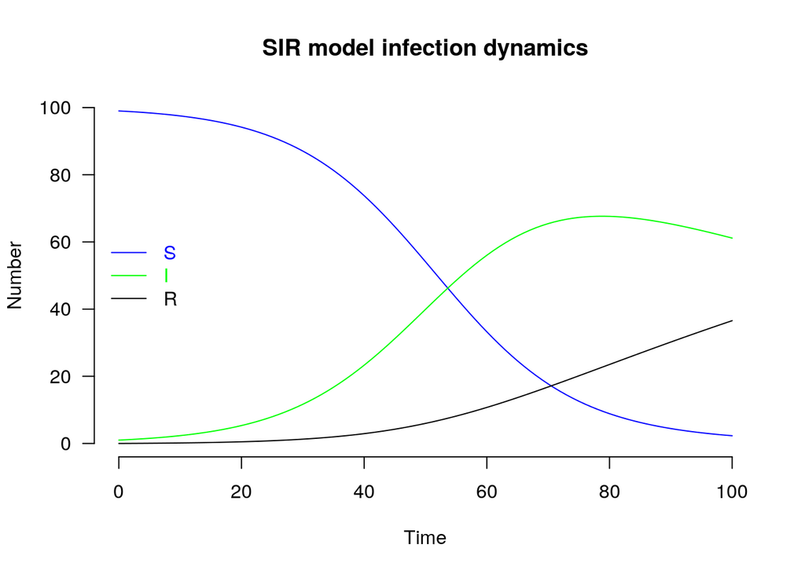

```r
# Plot the number of susceptibles in the population against time
plot(x=modelOutput$Time, y=modelOutput$S, # Coordinates to plot
     ylim=c(0, popSize), # Set minimum and maximum limits of the Y axis
     xlab="Time", # Define X axis label
     ylab="Number", # Define the Y axis label,
     main="SIR model infection dynamics", # Define the plot title
     type="l", # Plot a line through the coordinates
     col="blue", # Colour the plot blue
     las=1, # Make the tick labels on X and Y axes horizontal
     bty="n") # Remove the box around the plot

# Add a line for the number of infected individuals against time
points(x=modelOutput$Time, y=modelOutput$I, # Coordinates to ADD to current plot
       type="l",
       col="green")

# Add a line for the number of recovered individuals against time
points(x=modelOutput$Time, y=modelOutput$R, # Coordinates to ADD to current plot
       type="l",
       col="black")

# Add a legend to the plot
legend("left", # Position the legend at the left hand side of the current plot
       legend=c("S", "I", "R"), # Define the labels to present in plot
       lty=c(1,1,1), # Set the legend to associate a line with each label,
       col=c("blue", "green", "black"), # Set the colour of the lines,
       text.col=c("blue", "green", "black"), # Set the colour of the labels,
       bty="n")
```

## Exercises

1. How would you change the colours of the lines in the output plot?
2. What happens when you change the number of timesteps (`nTimesteps`) to 1000?
3. How does changing the `infectiousness` or `recovery` change the infection dynamics?
4. Change the model to include an exposed infection category, in which individuals have been exposed to infection but aren’t yet infectiousness, based on the following equations:
   $$\frac{dS}{dt} = -\frac{\beta * I * S}{N}\\
   \frac{dE}{dt} = \frac{\beta * I * S}{N} - p * E\\
   \frac{dI}{dt} = p * E - r*I\\
   \frac{dR}{dt} = r*I\\$$

# A stochastic model

## The Gillespie algorithm

A stochastic model is a model that incorporates stochasticity - randomness. The incoporation of randomness into a model makes it more realistic. In life, things aren’t all the same and events don’t always occur in the same way. Randomness can, to some extent, be used to capture this variation.

The Gillespie algorithm provides a means by which randomness can be introduced into the SIR model described above. It has four steps